# Notebook

[figure not shown]

Decision Making with Business Statistics

Week 4: Project: E-News Express

## Define Problem Statement and Objectives

**Context:**

The advent of e-news, or electronic news, portals has offered us a great opportunity to quickly get updates on the day-to-day events occurring globally. The information on these portals is retrieved electronically from online databases, processed using a variety of software, and then transmitted to the users. There are multiple advantages of transmitting news electronically, like faster access to the content and the ability to utilize different technologies such as audio, graphics, video, and other interactive elements that are either not being used or aren’t common yet in traditional newspapers.

E-news Express, an online news portal, aims to expand its business by acquiring new subscribers. With every visitor to the website taking certain actions based on their interest, the company plans to analyze these actions to understand user interests and determine how to drive better engagement. The executives at E-news Express believe that there has been a decline in new monthly subscribers compared to the past year because the current webpage is not designed well enough in terms of the outline & recommended content to keep customers engaged long enough to decide to subscribe.

[Companies often analyze user responses to two variants of a product to decide which of the two variants is more effective. This experimental technique, known as A/B testing, is used to determine whether a new feature attracts users based on a chosen metric.]

**Objective:**

The design team of the company has researched and created a new landing page that has a new outline & more relevant content compared to the old page. To test the effectiveness of the new landing page in gathering new subscribers, the Data Science team experimented by randomly selecting 100 users and dividing them equally into two groups. The existing landing page was served to the first group (control group) and the new landing page to the second group (treatment group). Data regarding the interaction of users in both groups with the two versions of the landing page was collected. Being a data scientist in E-news Express, you have been asked to explore the data and perform a statistical analysis (at a significance level of 5%) to determine the effectiveness of the new landing page in gathering new subscribers for the news portal by answering the following questions:

1. Do the users spend more time on the new landing page than on the existing landing page?
2. Is the conversion rate (the proportion of users who visit the landing page and get converted) for the new page greater than the conversion rate for the old page?
3. Does the converted status depend on the preferred language?
4. Is the time spent on the new page the same for the different language users?

**Data Dictionary:**

The data contains information regarding the interaction of users in both groups with the two versions of the landing page.

1. user_id - Unique user ID of the person visiting the website
2. group - Whether the user belongs to the first group (control) or the second group (treatment)
3. landing_page - Whether the landing page is new or old
4. time_spent_on_the_page - Time (in minutes) spent by the user on the landing page
5. converted - Whether the user gets converted to a subscriber of the news portal or not
6. language_preferred - language chosen by the user to view the landing page

## Import all the necessary libraries

```python
# Installing the libraries with the specified version.
!pip install --upgrade pip -q
!pip install numpy pandas matplotlib seaborn scipy -q
```

```
   ━━━━━━━━━━━━━━━━━━━━━━━━━━━━━━━━━━━━━━━━ 1.8/1.8 MB 14.3 MB/s eta 0:00:00
```

**Note**: *After running the above cell, kindly restart the notebook kernel and run all cells sequentially from the start again.*

# **Reading the Data into a DataFrame**

```python
# Import libraries for data manipulation
import numpy as np
import pandas as pd

# Import libraries for data visualization
import matplotlib.pyplot as plt
import seaborn as sns
```

```python
#Connect to Google drive
from google.colab import drive
drive.mount('/content/drive')
```

# **Importing the dataset**

```python
file_path = '/content/drive/MyDrive/Python Course/PGDSGA - Projects/abtest.csv'
```

```python
df= pd.read_csv(file_path)
```

## Explore the dataset and extract insights using Exploratory Data Analysis

- Data Overview
  - Viewing the first and last few rows of the dataset
  - Checking the shape of the dataset
  - Getting the statistical summary for the variables
- Check for missing values
- Check for duplicates

# **View the first and last 5 rows of the dataset**

```python
df.head() # Use head() to view first 5 rows of the dataset
```

|  | user_id | group | landing_page | time_spent_on_the_page | converted | language_preferred |
| --- | --- | --- | --- | --- | --- | --- |
| 0 | 546592 | control | old | 3.48 | no | Spanish |
| 1 | 546468 | treatment | new | 7.13 | yes | English |
| 2 | 546462 | treatment | new | 4.40 | no | Spanish |
| 3 | 546567 | control | old | 3.02 | no | French |
| 4 | 546459 | treatment | new | 4.75 | yes | Spanish |

```python
df.tail() # Use tail() to view last 5 rows of the dataset
```

|  | user_id | group | landing_page | time_spent_on_the_page | converted | language_preferred |
| --- | --- | --- | --- | --- | --- | --- |
| 95 | 546446 | treatment | new | 5.15 | no | Spanish |
| 96 | 546544 | control | old | 6.52 | yes | English |
| 97 | 546472 | treatment | new | 7.07 | yes | Spanish |
| 98 | 546481 | treatment | new | 6.20 | yes | Spanish |
| 99 | 546483 | treatment | new | 5.86 | yes | English |

```python
#Checking the shape of the dataset
print("There are",df.shape[0], 'rows and', df.shape[1], 'columns in the dataset.')
```

```
There are 100 rows and 6 columns in the dataset.
```

```python
#check the datatypes of the columns of the dataset
df.info()
```

```
<class 'pandas.core.frame.DataFrame'>
RangeIndex: 100 entries, 0 to 99
Data columns (total 6 columns):
 #   Column                  Non-Null Count  Dtype
---  ------                  --------------  -----
 0   user_id                 100 non-null    int64
 1   group                   100 non-null    object
 2   landing_page            100 non-null    object
 3   time_spent_on_the_page  100 non-null    float64
 4   converted               100 non-null    object
 5   language_preferred      100 non-null    object
dtypes: float64(1), int64(1), object(4)
memory usage: 4.8+ KB
```

There are 2 numerical columns and 4 object type columns

```python
df['converted'].unique()
```

```
array(['no', 'yes'], dtype=object)
```

```python
df['converted'].nunique()
```

```
2
```

```python
df['landing_page'].unique()
```

```
array(['old', 'new'], dtype=object)
```

```python
df['group'].unique()
```

```
array(['control', 'treatment'], dtype=object)
```

```python
df['language_preferred'].unique()
```

```
array(['Spanish', 'English', 'French'], dtype=object)
```

```python
#checking the count of different data types in landing_page
df['landing_page'].value_counts()
```

| landing_page | count |
| --- | --- |
| old | 50 |
| new | 50 |

**dtype:** int64

# **Check for Missing Values**

```python
df.isnull().sum()
```

|  | 0 |
| --- | --- |
| user_id | 0 |
| group | 0 |
| landing_page | 0 |
| time_spent_on_the_page | 0 |
| converted | 0 |
| language_preferred | 0 |

**dtype:** int64

- There are no Missing values in the dataset

# **Checking for Duplicates**

```python
df.duplicated().sum()
```

```
np.int64(0)
```

- There are 0 duplicate rows in the dataset

# **Checking for Statistical Summary of the data**

```python
df.describe().T
```

|  | count | mean | std | min | 25% | 50% | 75% | max |
| --- | --- | --- | --- | --- | --- | --- | --- | --- |
| user_id | 100.0 | 546517.0000 | 52.295779 | 546443.00 | 546467.75 | 546492.500 | 546567.2500 | 546592.00 |
| time_spent_on_the_page | 100.0 | 5.3778 | 2.378166 | 0.19 | 3.88 | 5.415 | 7.0225 | 10.71 |

- Users: There are 100 unique users. user_id is simply an identifier and does not carry analytical meaning.
- time_spent_on_the_page: on an average users spend 5.38 mins on the landing page.
- Std dev is approximately 2.38 mins.

### Univariate Analysis

**Univariate Analysis - Studying one variable at a time.**

```python
df.info()
```

```
<class 'pandas.core.frame.DataFrame'>
RangeIndex: 100 entries, 0 to 99
Data columns (total 6 columns):
 #   Column                  Non-Null Count  Dtype
---  ------                  --------------  -----
 0   user_id                 100 non-null    int64
 1   group                   100 non-null    object
 2   landing_page            100 non-null    object
 3   time_spent_on_the_page  100 non-null    float64
 4   converted               100 non-null    object
 5   language_preferred      100 non-null    object
dtypes: float64(1), int64(1), object(4)
memory usage: 4.8+ KB
```

**Variables:**

- Continuous - time_spent_on_the_page
- Categorical - group , landing_page, language_preferred.
- Binary categorical - converted

**Summary Statistics**

```python
df['time_spent_on_the_page'].describe()
```

|  | time_spent_on_the_page |
| --- | --- |
| count | 100.000000 |
| mean | 5.377800 |
| std | 2.378166 |
| min | 0.190000 |
| 25% | 3.880000 |
| 50% | 5.415000 |
| 75% | 7.022500 |
| max | 10.710000 |

**dtype:** float64

- **Skewness:** Mean is approximately 5.378, Median is approximately 5.415 which is very close. (left skewed)

**Distribution Plot --> Time spent on the Page**

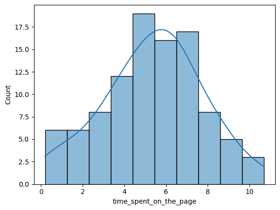

```python
 #Histogram on  time_spent_on_the_page
sns.histplot(data=df, x='time_spent_on_the_page', bins=10, kde=True, alpha=0.5)
plt.show()
```

**Skewness**

```python
df['time_spent_on_the_page'].skew()
```

```
np.float64(-0.1494803722510636)
```

- Mean (5.378) < Median (5.415) → slightly negative skew
- slightly left-skewed.

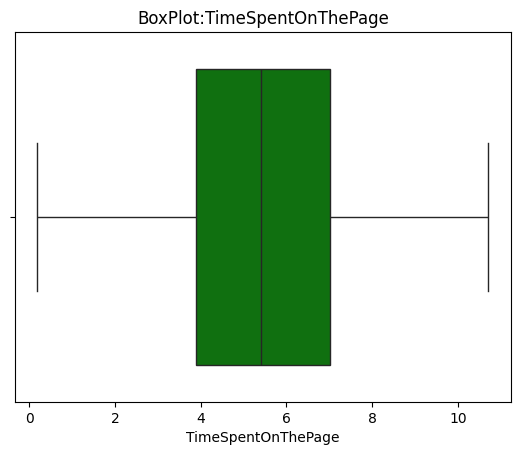

```python
#Creating  a boxplot with seaborn for time_spent_on_the_page
plt.title('BoxPlot:TimeSpentOnThePage')
plt.xlabel('TimeSpentOnThePage')
sns.axes_style('whitegrid')
sns.boxplot(data=df, x='time_spent_on_the_page',color='green')
plt.show()
```

```python
#Numerical Confirmation
print("Mean:", df['time_spent_on_the_page'].mean())
print("Median:", df['time_spent_on_the_page'].median())
print("Skew:", df['time_spent_on_the_page'].skew())
```

```
Mean: 5.377800000000001
Median: 5.415
Skew: -0.1494803722510636
```

```python
df['group'].value_counts()
```

| group | count |
| --- | --- |
| control | 50 |
| treatment | 50 |

**dtype:** int64

```
group
control      50
treatment    50
Name: count, dtype: int64
__________________________________________________
```

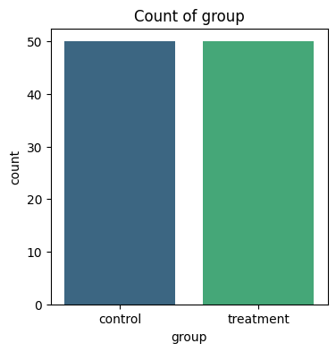

```
landing_page
old    50
new    50
Name: count, dtype: int64
__________________________________________________
```

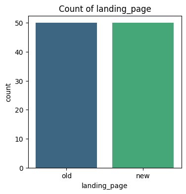

```
converted
yes    54
no     46
Name: count, dtype: int64
__________________________________________________
```

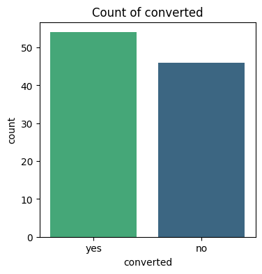

```
language_preferred
Spanish    34
French     34
English    32
Name: count, dtype: int64
__________________________________________________
```

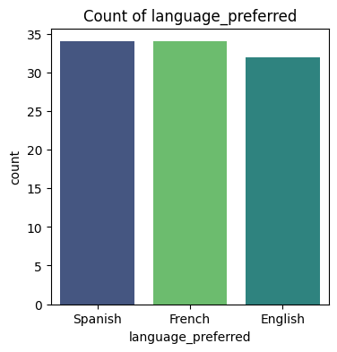

```python
#Making a list of all categorical variables
cat_cols = ['group', 'landing_page', 'converted', 'language_preferred']

#Printing the count of unique categorical levels in each column
for col in cat_cols:
  #Print Counts for each column in the dataset
    print(df[col].value_counts()) #sorts bars by frequency
    print("_" * 50)
    #Print countplot for each categorical clomn
    plt.figure(figsize =(4,4))
    sns.countplot(data=df, x=col, hue=col, palette='viridis',order=df[col].value_counts().index, legend=False)
    plt.title(f'Count of {col}')
    plt.show()
```

- There are 50 users in the control group and 50 users in the treatment group.
- 50 users were shown the old landing page and 50 users were shown the new landing page.
- 54 users converted (subscribed), and 46 users did not convert.
- Users selected three languages: Spanish (34), French (34), and English (32).

### Bivariate Analysis

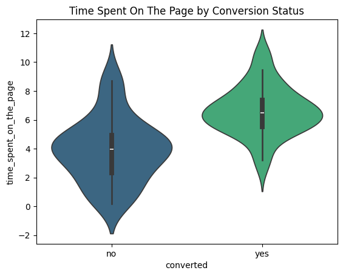

```python
#ViolinPlot
sns.violinplot(data=df, x='converted', y='time_spent_on_the_page', hue='converted', palette='viridis', inner='box')
plt.title('Time Spent On The Page by Conversion Status')
plt.show()
```

```python
# 1. Calculate stats for both groups at once
summary_stats = df.groupby('group')['time_spent_on_the_page'].agg(['mean', 'median', 'max','min'])

# 2. Display the results
print("Summary Statistics by Conversion Status:")
print(summary_stats)

def get_outliers(data):
    Q1 = data.quantile(0.25)
    Q3 = data.quantile(0.75)
    IQR = Q3 - Q1
    lower_bound = Q1 - 1.5 * IQR
    upper_bound = Q3 + 1.5 * IQR
    return data[(data < lower_bound) | (data > upper_bound)].tolist()

# Group by 'group' and apply the outlier function
outliers = df.groupby('group')['time_spent_on_the_page'].apply(get_outliers)

print("Outlier values per group:")
print(outliers)
```

```
Summary Statistics by Conversion Status:
             mean  median    max   min
group
control    4.5324   4.380  10.30  0.19
treatment  6.2232   6.105  10.71  1.65
Outlier values per group:
group
control                       []
treatment    [10.71, 1.65, 10.5]
Name: time_spent_on_the_page, dtype: object
```

**Studying the relationship between TWO variables - Group vs Time Spent**

**Boxplot to compare group variable and time_spent_on_the_page**

```python
df['group'].value_counts()
```

| group | count |
| --- | --- |
| control | 50 |
| treatment | 50 |

**dtype:** int64

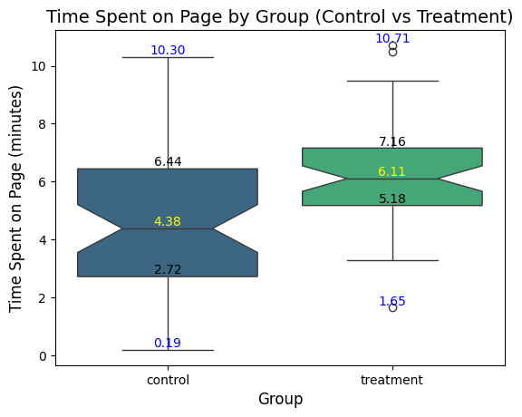

```python
#show min, Q1, median, Q3, max directly on the plot:
groups = df['group'].unique()  # Group = ['Control', 'Treatment']

for i, grp in enumerate(groups):
    data_col = df[df['group']==grp]['time_spent_on_the_page']
    q1 = np.percentile(data_col, 25)
    median = np.median(data_col)
    q3 = np.percentile(data_col, 75)
    min_val = data_col.min()
    max_val = data_col.max()

    plt.text(i, min_val, f"{min_val:.2f}", ha='center', va='bottom', color='blue')
    plt.text(i, q1, f"{q1:.2f}", ha='center', va='bottom', color='black')
    plt.text(i, median, f"{median:.2f}", ha='center', va='bottom', color='yellow')
    plt.text(i, q3, f"{q3:.2f}", ha='center', va='bottom', color='black')
    plt.text(i, max_val, f"{max_val:.2f}", ha='center', va='bottom', color='blue')

# Plot boxplot
sns.boxplot(data=df, x='group', y='time_spent_on_the_page', notch=True,hue='group', palette='viridis')
plt.title('Time Spent on Page by Group (Control vs Treatment)', fontsize=14)
plt.xlabel('Group', fontsize=12)
plt.ylabel('Time Spent on Page (minutes)', fontsize=12)
plt.show()
```

- Users in the first group (control) spend on an average of 4.53 mins on the landind page. {Median is 4.38 mins)
- Users in the second group(treatment) showa significantly higer engagement, with spending time on an average of 6.22 mins. (Median is 6.11)
- Control Group: Users spend between 0.19 minutes and 10.30 minutes on the page.
- Treatment Group: Users spend between 1.65 minutes and 10.71 minutes on the page.

## 1. Do the users spend more time on the new landing page than the existing landing page?

### Perform Visual Analysis

```python
df['landing_page'].value_counts()
```

| landing_page | count |
| --- | --- |
| old | 50 |
| new | 50 |

**dtype:** int64

```python
# 1. Calculate stats for new landing page
summary_stats = df.groupby('landing_page')['time_spent_on_the_page'].agg(['mean', 'median', 'max','min','std'])

# 2. Display the results
print("\033[1mSummary Statistics per Landing Page:\033[0m")
print(summary_stats)

def get_outliers(data):
    Q1 = data.quantile(0.25)
    Q3 = data.quantile(0.75)
    IQR = Q3 - Q1
    lower_bound = Q1 - 1.5 * IQR
    upper_bound = Q3 + 1.5 * IQR
    return data[(data < lower_bound) | (data > upper_bound)].tolist()

# Group by 'group' and apply the outlier function
outliers = df.groupby('landing_page')['time_spent_on_the_page'].apply(get_outliers)

print("\033[1mOutlier values per Landing Page:\033[0m")
print(outliers)
```

```
Summary Statistics per Landing Page:
                mean  median    max   min       std
landing_page
new           6.2232   6.105  10.71  1.65  1.817031
old           4.5324   4.380  10.30  0.19  2.581975
Outlier values per Landing Page:
landing_page
new    [10.71, 1.65, 10.5]
old                     []
Name: time_spent_on_the_page, dtype: object
```

- New landing page users spend more time on average.
- New page has 3 outliers.
- Old page has no outliers, meaning all values are within the expected range

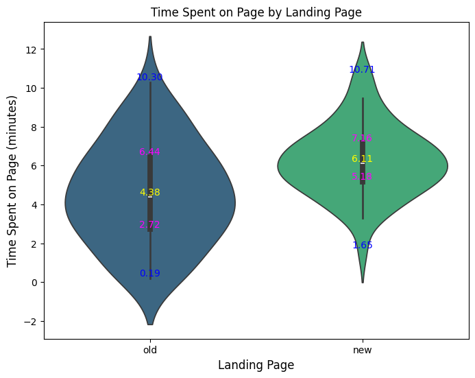

```python
# Categorical variable (landing_page) vs Continuous variable: numeric values ( time_spent_on_the_page)

# Using Violin Plot to visualize individual data points across categories
plt.figure(figsize=(8,6))
sns.violinplot(data=df, x='landing_page', y='time_spent_on_the_page', hue='landing_page', palette='viridis')


# Unique landing page values
groups = df['landing_page'].unique()  # landing_page values = ['old', 'new']

for i, grp in enumerate(groups):
  data_col = df[df['landing_page']==grp]['time_spent_on_the_page']
  #Calculate Stats
  q1 = np.percentile(data_col, 25)
  median = np.median(data_col)
  q3 = np.percentile(data_col, 75)
  min_val = data_col.min()
  max_val = data_col.max()

#show min, Q1, median, Q3, max directly on the plot:
  plt.text(i, min_val, f"{min_val:.2f}", ha='center', va='bottom', color='blue')
  plt.text(i, q1, f"{q1:.2f}", ha='center', va='bottom', color='magenta')
  plt.text(i, median, f"{median:.2f}", ha='center', va='bottom', color='yellow')
  plt.text(i, q3, f"{q3:.2f}", ha='center', va='bottom', color='magenta')
  plt.text(i, max_val, f"{max_val:.2f}", ha='center', va='bottom', color='blue')

#Labeling the plot
plt.title('Time Spent on Page by Landing Page')
plt.xlabel('Landing Page', fontsize=12)
plt.ylabel('Time Spent on Page (minutes)', fontsize=12)
plt.show()
```

- Users spend an average of 4.53 minutes on the old landing page (median: 4.38 minutes).
- Users on the new landing page show higher engagement, spending an average of 6.22 minutes (median: 6.11 minutes).
- On the old page, time spent ranges from 0.19 to 10.30 minutes.
- On the new page, time spent ranges from 1.65 to 10.71 minutes.

### Step 1: Define the null and alternate hypotheses

- H₀ (Null Hypothesis): Users on the new landing page do not spend more time than users on the old page (no difference in mean time spent).
- Hₐ (Alternative Hypothesis):Users on the new landing page spend more time than users on the old page.(Mean time spent is higher on the new page.)

### Step 2: Select Appropriate test

- We are comparing two independent groups (old vs new landing page) with sample standard deviations only. Therefore, a one-tailed independent-samples t-test is the correct choice to test whether users on the new page spend more time than users on the old page.
- One-tailed test --> Testing if new page > old page
- Two population means --> Comparing mean time spent for old vs new landing page
- Two independent populations --> Users on old vs new pages are different groups
- Population standard deviations are unknown (not given)

### Step 3: Decide the significance level

- significance level of 5% is given. alpha = 0.05.

### Step 4: Collect and prepare data

```python
import scipy.stats as stats
# Separate the groups
old_page = df[df['landing_page'] == 'old']['time_spent_on_the_page']
new_page = df[df['landing_page'] == 'new']['time_spent_on_the_page']
print('The sample standard deviation of the time spent on the old page is:', round(old_page.std(),2))
print('The sample standard deviation of the time spent on the new page is:', round(new_page.std(),2))
```

```
The sample standard deviation of the time spent on the old page is: 2.58
The sample standard deviation of the time spent on the new page is: 1.82
```

```python
#Calculate ratio to determine the Population stand deviation are equal or not.
std_old = old_page.std()
std_new = new_page.std()
larger_std = max(std_old, std_new)
smaller_std = min(std_old, std_new)

# Calculate the ratio
std_ratio = larger_std / smaller_std

print('Ratio of larger to smaller std:', round(std_ratio,2))
```

```
Ratio of larger to smaller std: 1.42
```

- The sample standard deviation for the old landing page is 2.58, and for the new landing page, it is 1.82. The ratio of the larger to the smaller standard deviation is 1.42. Because this ratio is less than the common threshold of 2, we conclude that the population variances are equal, and therefore the population standard deviations are also equal.

### Step 5: Calculate the p-value

```python
# Import the t-test ind function
from scipy.stats import ttest_ind

# Calculate the t-test and p-value
test_stat, p_value = ttest_ind(new_page, old_page, equal_var=True, alternative='greater')

print('The p-value is', p_value)
```

```
The p-value is 0.0001316123528095005
```

- The p-value is 0.0001316123528095005

### Step 6: Compare the p-value with $\alpha$

```python
alpha = 0.05  # 5% significance level
if  p_value < alpha:
    print(f'As the p-value {p_value} is less than the level of significance, we reject the null hypothesis.')
else:
    print(f'As the p-value {p_value} is greater than the level of significance, we fail to reject the null hypothesis.')
```

```
As the p-value 0.0001316123528095005 is less than the level of significance, we reject the null hypothesis.
```

### Step 7: Draw inference

- Based on the T-test results, since the p-value is significantly lower than 0.05, we reject the null hypothesis. We have sufficient statistical evidence at a 95% confidence level to conclude that users on the new landing page spend significantly more time on the page than users on the old landing page. Therefore, the new landing page is more effective at driving user engagement.

## 2. Is the conversion rate (the proportion of users who visit the landing page and get converted) for the new page greater than the conversion rate for the old page?

```python
df['converted'].value_counts()
```

| converted | count |
| --- | --- |
| yes | 54 |
| no | 46 |

**dtype:** int64

# **Perform Visual Analysis**

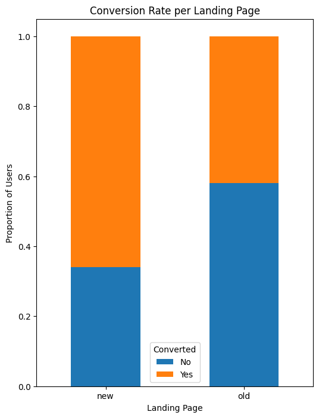

```python
# Crosstab to get proportion of conversions per landing page
pd.crosstab(df['landing_page'], df['converted'], normalize='index').plot(
    kind="bar",
    figsize=(6,8),
    stacked=True,
   )

plt.title("Conversion Rate per Landing Page")
plt.xlabel("Landing Page")
plt.ylabel("Proportion of Users")
plt.legend(title="Converted", labels=['No', 'Yes'])
plt.xticks(rotation=0)
plt.show()
```

- Each bar represents a landing page.
- The stacked segments show proportion of users who converted vs did not convert.
- In the plot the "Yes" section for the new page is visibly larger then the "Yes" section for the old page.

**Step 1: Define the null and alternate hypotheses**

- H₀ (Null Hypothesis): - The new page does not have a higher conversion rate than the old page.
- Hₐ (Alternative Hypothesis): The new page has a higher conversion rate than the old page.

**Step 2: Select Appropriate test**

- Since this is: One-tailed test c omparing two population proportions from two independent groups (new page vs old page)
- This is a one-tailed two-sample z-test

**Step 3: Decide the significance level**

- As given we select α = 0.05.

**Step 4: Collect and prepare data**

```python
# Counting conversions for each group
converted_new = df[df['landing_page'] == 'new']['converted'].value_counts()['yes'] # get rows of landing page data where New
converted_old = df[df['landing_page'] == 'old']['converted'].value_counts()['yes'] # get rows of landing page data where Old

# Counting total number of users in each group
n_new = df[df['landing_page'] == 'new'].shape[0]
n_old = df[df['landing_page'] == 'old'].shape[0]

print(f'Conversions (New, Old): {converted_new}, {converted_old}')
print(f'Count of Users (New, Old): {n_new}, {n_old}')
```

```
Conversions (New, Old): 33, 21
Count of Users (New, Old): 50, 50
```

```python
conversion_rate_new = converted_new / n_new # the count of users who converted on the new page (converted_new) by the total number of users who saw the new page
conversion_rate_old = converted_old / n_old

print(f'Conversion Rate for New Page: {conversion_rate_new:.2%}')
print(f'Conversion Rate for Old Page: {conversion_rate_old:.2%}')
```

```
Conversion Rate for New Page: 66.00%
Conversion Rate for Old Page: 42.00%
```

**Step 5: Calculate the p-value**

```python
# Import the required function
from statsmodels.stats.proportion import proportions_ztest

# Perform one-tailed two-proportion z-test
test_stat, p_value = proportions_ztest(
    [converted_new, converted_old],   # successes
    [n_new, n_old],                   # total observations
    alternative='larger'              # Ha: new > old
)

print(f"Z-statistic: {test_stat:.4f}")
print(f"P-value: {p_value:.6f}")
```

```
Z-statistic: 2.4077
P-value: 0.008026
```

**Step 6: Compare the p-value with α**

```python
alpha = 0.05  # significance level

if p_value < alpha:
    print(f"As the p-value ({p_value:.4f}) is less than the significance level ({alpha}), we reject the null hypothesis.")
    print("Conclusion: The new landing page has a significantly higher conversion rate than the old page.")
else:
    print(f"As the p-value ({p_value:.4f}) is greater than the significance level ({alpha}), we fail to reject the null hypothesis.")
    print("Conclusion: There is no statistically significant evidence that the new page performs better.")
```

```
As the p-value (0.0080) is less than the significance level (0.05), we reject the null hypothesis.
Conclusion: The new landing page has a significantly higher conversion rate than the old page.
```

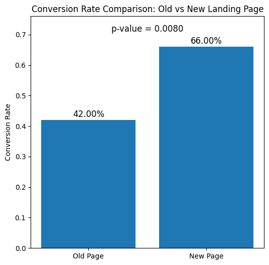

```python
# Conversion rates
conversion_rates = [conversion_rate_old, conversion_rate_new]
pages = ['Old Page', 'New Page']

# Create bar chart
plt.figure(figsize=(6,6))
bars = plt.bar(pages, conversion_rates)

# Label bars with conversion rates
for bar, rate in zip(bars, conversion_rates):
    height = bar.get_height()
    plt.text(bar.get_x() + bar.get_width()/2, height + 0.01, f'{rate:.2%}', ha='center', fontsize=12)

# Add p-value annotation
plt.text(0.5, max(conversion_rates) + 0.05, f'p-value = {p_value:.4f}', ha='center', fontsize=12)

# Labels and title
plt.ylabel('Conversion Rate')
plt.title('Conversion Rate Comparison: Old vs New Landing Page')
plt.ylim(0, max(conversion_rates)+0.1)
plt.show()
```

**Step 7: Draw inference**

- The statistical analysis shows that the new landing page performs significantly better than the old page in terms of user conversions. With a p-value of 0.008, which is well below the significance level of 0.05, we reject the null hypothesis that the new page has the same or lower conversion rate.
- This indicates that the increase in conversion rate for the new page is unlikely due to random chance. In practical terms, the new landing page is more effective at converting visitors, suggesting that it should be adopted for better business outcomes.

## 3. Is the conversion and preferred language are independent or related?

**Perform Visual Analysis**

```python
# Count of users by preferred language
language_counts = df['language_preferred'].value_counts()
print(language_counts)
```

```
language_preferred
Spanish    34
French     34
English    32
Name: count, dtype: int64
```

```python
# Cross-tab of conversion by language
conversion_pct = pd.crosstab(df['language_preferred'], df['converted'], normalize='index') * 100

print(conversion_pct)
```

```
converted                  no        yes
language_preferred
English             34.375000  65.625000
French              55.882353  44.117647
Spanish             47.058824  52.941176
```

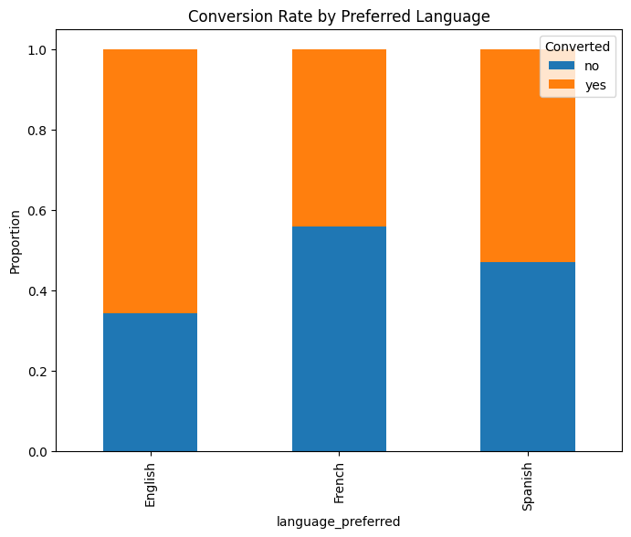

```python
pd.crosstab(df['language_preferred'], df['converted'], normalize='index')\
  .plot(kind="bar", stacked=True, figsize=(8,6))

plt.ylabel("Proportion")
plt.title("Conversion Rate by Preferred Language")
plt.legend(title="Converted")
plt.show()
```

**Step 1: Define the null and alternate hypotheses**

$H_0:$ Conversion is independent of language preferred.

$H_a:$ Conversion is dependent on language preferred.

**Step 2: Select Appropriate test**

**Problem type:** Test of independence - as we are testing conversion and preferred language are independent or related

**Variables:**

- Converted status --> categorical (Yes/No)
- Preferred language --> categorical (English, Spanish, French)
- Chi-square test is designed to check whether two categorical variables are independent or related
- The appropriate test for this Hypotheses is Chi-square test of independence

**Step 3: Decide the significance level**

As given in the problem statement, we select α = 0.05.

**Step 4: Collect and prepare data**

```python
#   contingency table
contingency_table = pd.crosstab(df['language_preferred'], df['converted'])

contingency_table
```

| converted language_preferred | no | yes |
| --- | --- | --- |
| English | 11 | 21 |
| French | 19 | 15 |
| Spanish | 16 | 18 |

**Total users per language**

- English: 11 + 21 = 32
- French: 19 + 15 = 34
- Spanish: 16 + 18 = 34

**Step 5: Calculate the p-value**

```python
# Import the required function
from scipy.stats import chi2_contingency  # Chi-square test for independence

# Perform the Chi-square test
# Input: contingency table of observed counts
# Output: chi2 statistic, p-value, degrees of freedom, expected frequencies
chi2, p_value, dof, exp_freq = chi2_contingency(contingency_table)

# Step 3: Print the p-value
print('The p-value is', p_value)  # If p-value < 0.05, reject H0: conversion depends on language
```

```
The p-value is 0.2129888748754345
```

**Step 6: Compare the p-value with α**

```python
# print the conclusion based on p-value
alpha = 0.05
if p_value < alpha:
    print(f'As the p-value {p_value} is less than the level of significance, we reject the null hypothesis.')
else:
    print(f'As the p-value {p_value} is greater than the level of significance, we fail to reject the null hypothesis.')
```

```
As the p-value 0.2129888748754345 is greater than the level of significance, we fail to reject the null hypothesis.
```

**Step 7: Draw inference**

- As the p-value (0.213) is greater than the significance level (α = 0.05), we fail to reject the null hypothesis. This indicates that conversion is independent of preferred language in this dataset, and any differences in observed conversion rates are not statistically significant.

## 4. Is the time spent on the new page same for the different language users?

**Perform Visual Analysis**

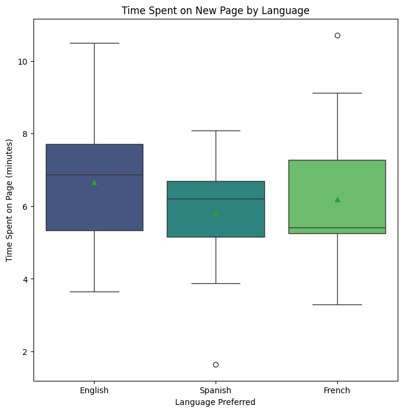

| language_preferred | time_spent_on_the_page |
| --- | --- |
| English | 6.663750 |
| French | 6.196471 |
| Spanish | 5.835294 |

**dtype:** float64

```python
df_new = df[df['landing_page'] == 'new']
# Visualize time spent on the new page for different language users
plt.figure(figsize=(8,8))
sns.boxplot(x='language_preferred', y='time_spent_on_the_page', showmeans=True, data=df_new,hue = 'language_preferred',palette = 'viridis')
plt.title('Time Spent on New Page by Language')
plt.xlabel('Language Preferred')
plt.ylabel('Time Spent on Page (minutes)')
plt.show()

# Calculate mean time spent on the new page for different language users
df_new.groupby(['language_preferred'])['time_spent_on_the_page'].mean()
```

- English users spend the most time on the new page on average.
- Spanish users spend the least time.
- The differences are small but noticeable, a statistical test will confirm if they're significant.

**Step 1: Define the null and alternate hypotheses**

- H₀ (Null Hypothesis): All language users spend the same time on the new page.
- Hₐ (Alternative Hypothesis): At least one language group spends a different amount of time.

**Step 2: Select Appropriate test**

Since this problem involves comparing the means of three independent groups (English, French, Spanish users), the appropriate test is:

**One-way ANOVA (Analysis of Variance)**

Why ANOVA?

- There are more than two groups (3 languages).
- We want to test if the population means are equal.
- Assumes the data is approximately normal and variances are similar.

**Step 3: Decide the significance level**

select α = 0.05.

**Step 4: Collect and prepare data**

```python
# create a subsetted data frame of the time spent on the new page by English language users
time_spent_English = df_new[df_new['language_preferred']=="English"]['time_spent_on_the_page']

# create subsetted data frames of the time spent on the new page by French and Spanish language users
time_spent_French = df_new[df_new['language_preferred']=="French"]['time_spent_on_the_page']
time_spent_Spanish = df_new[df_new['language_preferred']=="Spanish"]['time_spent_on_the_page']

# Summary statistics for each language group
print("English Users:\n", time_spent_English.describe(), "\n")
print("French Users:\n", time_spent_French.describe(), "\n")
print("Spanish Users:\n", time_spent_Spanish.describe())
```

```
English Users:
 count    16.00000
mean      6.66375
std       1.98415
min       3.65000
25%       5.32750
50%       6.86500
75%       7.71250
max      10.50000
Name: time_spent_on_the_page, dtype: float64

French Users:
 count    17.000000
mean      6.196471
std       1.933394
min       3.300000
25%       5.250000
50%       5.420000
75%       7.270000
max      10.710000
Name: time_spent_on_the_page, dtype: float64

Spanish Users:
 count    17.000000
mean      5.835294
std       1.525656
min       1.650000
25%       5.150000
50%       6.200000
75%       6.700000
max       8.080000
Name: time_spent_on_the_page, dtype: float64
```

**Observations**

1. English Users
- Sample size: 16 users
- Average time spent: 6.66 minutes (highest among the groups)
- Standard deviation 1.98, showing moderate variation
- Range: 3.65 to 10.50 minutes
- Median: 6.87 minutes, slightly higher than the mean --> slight left skew
2. French Users
- Sample size: 17 users
- Average time spent: 6.20 minutes (moderate)
- Standard deviation 1.93, similar variability to English users
- Range: 3.30 to 10.71 minutes
- Median: 5.42 minutes, lower than the mean --> slight right skew
3. Spanish Users
- Sample size: 17 users
- Average time spent: 5.84 minutes (lowest among the groups)
- Standard deviation 1.53, less variability than English and French
- Range: 1.65 to 8.08 minutes
- Median: 6.20 minutes, close to the mean --> fairly symmetric distribution

```python
df.info()
```

```
<class 'pandas.core.frame.DataFrame'>
RangeIndex: 100 entries, 0 to 99
Data columns (total 6 columns):
 #   Column                  Non-Null Count  Dtype
---  ------                  --------------  -----
 0   user_id                 100 non-null    int64
 1   group                   100 non-null    object
 2   landing_page            100 non-null    object
 3   time_spent_on_the_page  100 non-null    float64
 4   converted               100 non-null    object
 5   language_preferred      100 non-null    object
dtypes: float64(1), int64(1), object(4)
memory usage: 4.8+ KB
```

**Step 5: Calculate the p-value**

```python
# Import the required function
from scipy.stats import f_oneway

# Calculate the ANOVA test statistic and p-value
test_stat, p_value = f_oneway(time_spent_English, time_spent_French, time_spent_Spanish)

print('The p-value is', p_value)
```

```
The p-value is 0.43204138694325955
```

**Step 6: Compare the p-value with α**

```python
# print the conclusion based on p-value
alpha = 0.05
if p_value < alpha:
    print(f'As the p-value {p_value} is less than the level of significance, we reject the null hypothesis.')
else:
    print(f'As the p-value {p_value} is greater than the level of significance, we fail to reject the null hypothesis.')
```

```
As the p-value 0.43204138694325955 is greater than the level of significance, we fail to reject the null hypothesis.
```

**Step 7: Draw inference**

- There is no statistically significant difference in the average time spent on the new page among English, French, and Spanish users. While English users spend slightly more time on average and Spanish users slightly less, these differences are not large enough to be considered statistically meaningful. Therefore, any observed variations in the mean time spent are likely due to random fluctuations in the sample rather than being caused by language preference. This suggests that language does not have a significant impact on how long users stay on the new page.

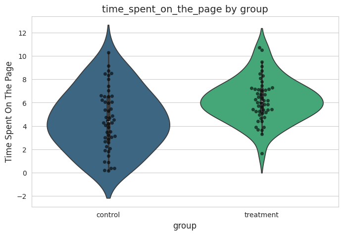

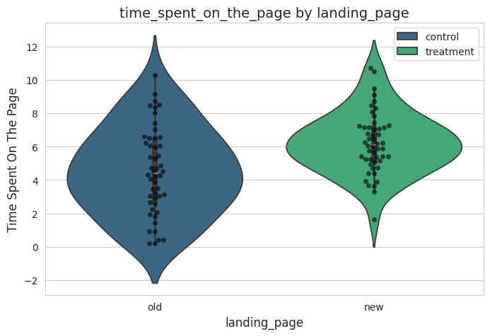

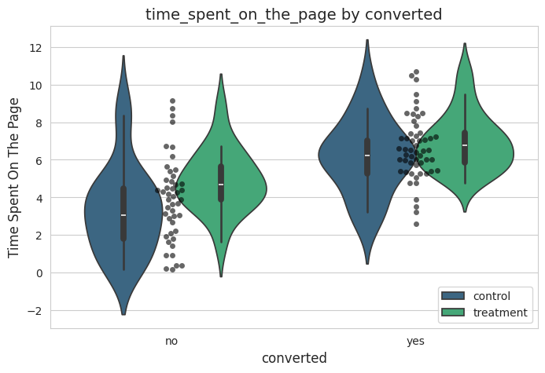

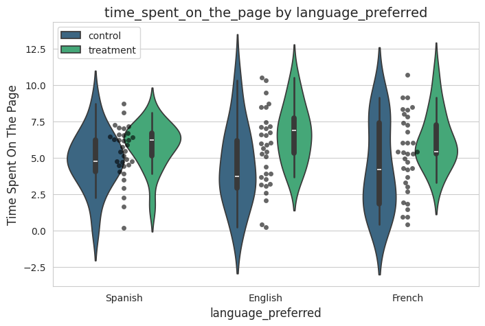

```python
import matplotlib.pyplot as plt
import seaborn as sns

# Set Seaborn style
sns.set_style('whitegrid')

# Continuous variable
num_var = 'time_spent_on_the_page'

# Categorical variables
cat_vars = ['group', 'landing_page', 'converted', 'language_preferred']

# Loop through each categorical variable
for cat in cat_vars:
    plt.figure(figsize=(8,5))

    # Violin plot (distribution + density)
    sns.violinplot(data=df, x=cat, y=num_var, inner='box', hue = 'group',palette='viridis')

    # Swarm plot (individual points)
    sns.swarmplot(data=df, x=cat, y=num_var, color='black', alpha=0.6)

    # Titles and labels
    plt.title(f'{num_var} by {cat}', fontsize=14)
    plt.xlabel(cat, fontsize=12)
    plt.ylabel(num_var.replace('_',' ').title(), fontsize=12)

    plt.show()
```